# Modelos y Simulación

## Trabajo Práctico N°3:

## Generación de números aleatorios

### Alumno: Barea Matias

### Profesores: Lic. Claudia López de Munain - Lic. Bruno Alfredo Pazos

### Respuestas:

1. R permite la generacion de numeros aleatorios de manera nativa. En este ambiente es un requerimiento esencial para en investigacion cientifica. Entre las herramientas implementadas en el paquete base de R podemos destacar:
- set.seed(entero): permite establecer la semilla (y el generador).
- RNGkind(): selecciona el generador.
- rdistribución(n,...): genera valores aleatorios de la correspondiente distribución. Por ejemplo, runif(n, min = 0, max = 1), generaría n valores de una uniforme. Se puede acceder al listado completo de las funciones disponibles en el paquete stats mediante el comando ?distributions.
- sample(): genera muestras aleatorias de variables discretas y permutaciones (se tratará en el Capítulo 5).
- simulate(): genera realizaciones de la respuesta de un modelo ajustado.

  Tambien es posible generar muestras aleatorias utilizando funciones incorporadas como runif(), rnorm(), rpois() y rexp() para distribuciones uniforme, normal, de Poisson y exponencial respectivamente.

  A modo de ejemplo se genero una muestra de 100 numeros de esta manera:

```python
muestra <- sample(seq(0, 1, by = 0.01), 100, replace = TRUE)
print(muestra)
```

```
  [1] 0.56 0.87 0.06 0.66 0.05 0.97 0.70 0.75 0.33 0.96 0.90 0.98 0.66 0.09 0.41
 [16] 0.80 0.16 0.97 0.48 0.75 0.90 0.78 0.26 0.51 0.23 0.71 0.28 0.50 0.53 0.47
 [31] 0.96 0.00 0.82 0.62 0.93 0.86 0.16 0.71 0.93 0.28 0.95 0.91 0.97 0.62 1.00
 [46] 0.88 0.22 0.48 0.07 0.14 0.90 0.45 0.70 0.92 0.27 0.76 0.94 0.37 0.99 0.84
 [61] 0.63 0.17 0.69 0.81 0.34 0.33 0.21 0.77 0.45 0.59 0.99 0.92 0.25 0.49 0.88
 [76] 0.41 0.55 0.72 0.03 0.37 0.34 0.07 0.55 0.16 0.80 0.76 0.87 0.80 0.32 0.90
 [91] 0.64 0.38 0.43 0.64 0.75 0.27 0.83 0.75 0.21 0.93
```

a) Calcular la media

```python
media <- mean(muestra) # Media
print(media)
```

```
[1] 0.5893
```

b) Calcular el desvio estandar

```python
desvio_estandar <- sd(muestra) # Desvio estandar
print(desvio_estandar)
```

```
[1] 0.2936852
```

c) Calcular la varianza

```python
varianza <- var(muestra) # Varianza
print(varianza)
```

```
[1] 0.08625102
```

d) Los graficos tambien pueden ser generados de manera nativa metiante la funcion `hist()`. El histograma es el gráfico más habitual para representar datos continuos que representa las frecuencias en las que aparecen las mediciones agrupadas en ciertos intervalos y cuenta cuántas observaciones caen en cada intervalo. Además, la altura está determinada por el ratio entre la frecuencia y el ancho del intervalo. Con la funcion `hist` pueden encontrar diferentes opciones gráficas. Por ejemplo:

Con border = “blue” y col = “orange”, puede cambiar los colores de las barras y de los bordes.

Cuando hay múltiples diagramas, puede utilizar la opción col=c(“darkblue”,“red”, “yellow”, “green”, “orange”, “violet”).

Con las = c(0, 1,2,3), se seleccionan las orientaciones de los textos: las=0 (paralelo a los ejes, por defecto), las=1 (horizontal), las=2 (perpendicular) y las=3 (vertical).

La opción horiz=TRUE crea un diagrama horizontal.

Los títulos de las etiquetas se pueden escribir así: xlab = expression(‘X’[2]), main = ’’, ylab="“, names.arg=c(”Primer nombre“,”Segundo nombre").

Los límites de los ejes se pueden modificar, por ejemplo, así: xlim = c(0, 1), ylim = c(0, 100).

Con la opción breaks se da un valor con el cual se indica el número aproximado de intervalos de clases o un vector cuyos elementos indican los puntos límites entre las clases o intervalos.

Con las opciones prob=TRUE, freq= F, freq=FALSE o freq=cumsum(F), el gráfico se construye con frecuencias relativas.

La función `abline` sirve para añadir una línea a un gráfico. Esta función tiene varios parametros con nombre, que sirven para especificar de forma sencilla distintos tipos de líneas:

`abline(a, b)`: línea de pendiente b y ordenada en el origen a `abline(h=y)`: línea horizontal `abline(v=x)`: línea vertical

[figure not shown]

```python
hist(muestra, breaks=10, col='lightblue', border='black', xlab='Valor', ylab='Frecuencia', main='Histograma de la muestra generada') # Histograma

abline(v=media, col='red', lwd=2) # Linea para mostrar la media
abline(v=c(media - desvio_estandar, media + desvio_estandar), col='blue', lwd=2, lty=2) # Linea de la desvio estandar

legend('topright', legend=c('Media', 'Desvio estandar'), col=c('red', 'blue'), lwd=2, lty=1:2) # Leyenda del grafico
```

1. Python permite la generacion de numeros aleatorios de manera nativa utilizando `random` o haciendo uso de la libreria `numpy`.

```python
import random # Importar modulo

num_random = [random.randint(0, 100) for _ in range(100)]
print(num_random)
```

[output not shown]

El modulo `random` implementa generadores de números pseudoaleatorios para varias distribuciones. Para los enteros, existe una selección uniforme dentro de un rango. Para las secuencias, existe una selección uniforme de un elemento aleatorio, una función para generar una permutación aleatoria de una lista in-situ y una función para el muestreo aleatorio sin reemplazo. Para números reales, existen funciones para calcular distribuciones uniformes, normales (Gaussianas), log-normales, exponenciales negativas, gamma y beta. Para generar distribuciones angulares está disponible la distribución de von Mises.

```python
import numpy as np # Importar la libreria

num_numpy = np.random.randint(0, 100, 100)
print(num_numpy)
```

```
[ 6 89 17 23  5 13 22 56 30 16  3 31 90 18 65 11 11 21 31 91 86 97 18 13
 22 55 43 39 12 26 96 40 19 29 10 39 53  2 20 25 63  1 33 79 15 93 75 51
 88 87 37 64 51  0 51 34 93  1  2 28 62 69  4 91 43 77 99 44 98 57 67 16
 49  5 62 55 85 53 87 74 52 35 31 64 80 71 50  3 59 20 11 10 38 67 51 86
 79 75 38 69]
```

La libreria `numpy` proporciona un objeto de matriz multidimensional, varios objetos derivados (como matrices y matrices enmascaradas) y una variedad de rutinas para operaciones rápidas en matrices, incluidas matemáticas, lógicas, manipulación de formas, clasificación, selección, etc. La funcion que utilizaremos es numpy.random para generar un arreglo psudoaleatorio de numeros.

Tambien podemos generar numeros aleatorios siguiendo una distribucion probabilistica normal de la siguiente manera utilizando random.normal(loc=0, scale=1, size=X) Donde:

Los parametros de entrada son:

- loc: media de la distribucion
- scale: el desvio estandar
- size: la cantidad de muestras

Y retorna muestras extraídas de la distribución normal parametrizada.

```python
muestra = np.random.normal(loc=0, scale=0.1, size=100)
print(muestra)
```

```
[ 0.13441074  0.02493733  0.07085864  0.26278454 -0.04976924  0.04128736
 -0.09227752 -0.06697606 -0.08855524 -0.04041679 -0.02722449  0.08522368
  0.03593581  0.06374877  0.00080934 -0.10408168  0.01599037 -0.06111268
  0.27126669 -0.12112244 -0.00913231 -0.0876761  -0.07183819  0.06893497
  0.07035275 -0.01438151  0.09455066  0.03404377 -0.04280252  0.16286581
  0.229524    0.09418346 -0.04011265  0.20348545  0.1487059  -0.12190572
 -0.01377754  0.07761673 -0.03501142 -0.15820409  0.2010923  -0.21672687
  0.02366989  0.14562695  0.12844709  0.07352581 -0.09958862 -0.0768323
  0.02261274  0.10190051  0.03942341 -0.06129774 -0.1954295  -0.06505623
 -0.0065471  -0.11221123  0.20127056 -0.16618629  0.07883869  0.0883548
  0.11243756 -0.12814458  0.2244229   0.01606856  0.09892927 -0.0715977
 -0.0457806   0.03382012  0.11470521 -0.01221086 -0.00315977  0.09596981
  0.14765565  0.01889655 -0.22823099  0.08216038 -0.0644213   0.03581866
  0.0199885  -0.03809087 -0.12307313  0.13126905 -0.00204641  0.09524104
 -0.19185473  0.11973489  0.14423069 -0.01440935 -0.08962404 -0.128803
  0.05980994  0.19573223  0.06126761  0.12255595  0.13947203  0.05307015
 -0.03526414 -0.09657946  0.03526235 -0.07777755]
```

Podremos calcular la media, el desvio estandar y la varianza utilizando las funciones `numpy.mean()` para calcular la media,`numpy.std()` para calcular el desvio estandar y `numpy.var()` para calcular la varianza de la siguiente manera:

a) Calcula la media.

```python
media = np.mean(muestra)
print("Valor de la media: ",media)
```

```
Valor de la media:  0.01857476069138362
```

b) Calcular el desvio estandar

```python
desvio = np.std(muestra)
print("Valor del desvio estandar: ", desvio)
```

```
Valor del desvio estandar:  0.10884204492521152
```

c) Calcular la varianza

```python
varianza = np.var(muestra)
print("Valor de la varianza: ", varianza)
```

```
Valor de la varianza:  0.01184659074350176
```

d) Los graficos se pueden generar a partir del uso de librerias, como puede ser `matplotlib` la cual proporciona una API orientada a objetos para incrustra graficos en aplicaciones que utilizan kits de herramientas GUI de uso general como Tkinter, wxPython, Qt o GTK. Ampliamnete utilizada para crear graficos de alta calidad en diferentes formatos y estilos y una herramienta fundamental para la visualizacion de datos en el ambito cientifico, de ingenieria y de analisis de datos entre muchas otras areas. Con ella es posible crear un histograma para representar graficamente la distribucion de la muestra generada.

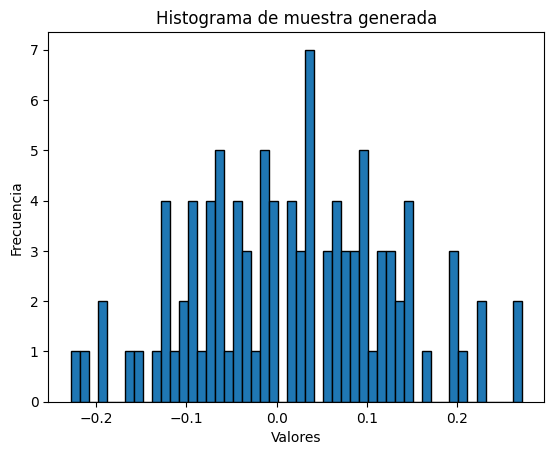

```python
import matplotlib.pyplot as plt

plt.hist(muestra, bins=50, edgecolor='black')
plt.xlabel('Valores')
plt.ylabel('Frecuencia')
plt.title('Histograma de muestra generada')
plt.show()
```

2. a) Uniforme, con parámetros: Min: 0, Max: 1.

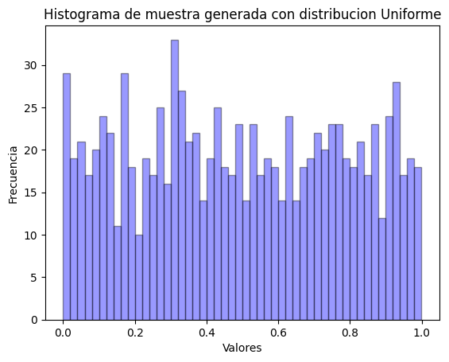

```python
distr_uniforme = np.random.uniform(0, 1, 1000)

plt.hist(distr_uniforme, bins=50, color='blue', alpha=0.4, edgecolor='black')
plt.title('Histograma de muestra generada con distribucion Uniforme')
plt.xlabel('Valores')
plt.ylabel('Frecuencia')
plt.show()
```

b) Normal, con parámetros: Media: 0, Desvío: 1.

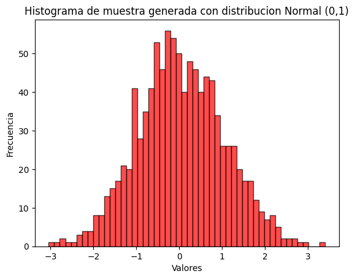

```python
distr_normal = np.random.normal(0, 1, 1000)

plt.hist(distr_normal, bins=50, color='red', alpha=0.7, edgecolor='black')
plt.title('Histograma de muestra generada con distribucion Normal (0,1)')
plt.xlabel('Valores')
plt.ylabel('Frecuencia')
plt.show()
```

c) Poisson, con parámetro: λ = 6.

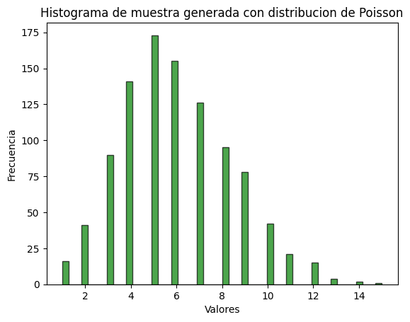

```python
distr_poisson = np.random.poisson(6, 1000)

plt.hist(distr_poisson, bins=50, color='green', alpha=0.7,  edgecolor='black')
plt.title('Histograma de muestra generada con distribucion de Poisson')
plt.xlabel('Valores')
plt.ylabel('Frecuencia')
plt.show()
```

d) Exponencial, con parámetro: β = 3 / 4

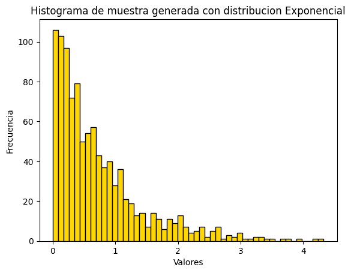

```python
distr_exponencial = np.random.exponential(3/4, 1000)

plt.hist(distr_exponencial, bins=50, color='gold', edgecolor='black')
plt.title('Histograma de muestra generada con distribucion Exponencial')
plt.xlabel('Valores')
plt.ylabel('Frecuencia')
plt.show()
```

a. Siguiendo la formula X = - (1/λ) ln(U) donde U es la muestra con distribucion uniforme y 1/λ es beta.

```python
def transformacion_exponencial(muestra, beta):
    return -beta * np.log(1 - muestra)
```

```python
exponencial_con_beta12 = transformacion_exponencial(distr_uniforme, 12)
```

b. Grafico:

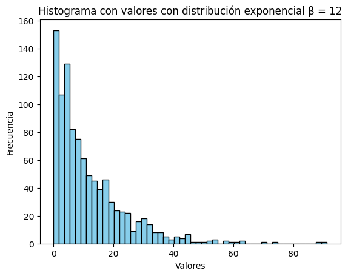

```python
plt.hist(exponencial_con_beta12, bins=50, color='skyblue', edgecolor='black')
plt.title('Histograma con valores con distribución exponencial β = 12')
plt.xlabel('Valores')
plt.ylabel('Frecuencia')
plt.show()
```

c. Generar 100 numeros aleatorios con distribucion exponencial con parametro β = 3

```python
exponencial_100_beta3 = np.random.exponential(3, 100)
```

d. Generar 1000 numeros aleatorios con distribucion exponencial con parametro β = 3

```python
exponencial_1000_beta3 = np.random.exponential(3, 1000)
```

e. Comparacion grafica del inciso c y d.

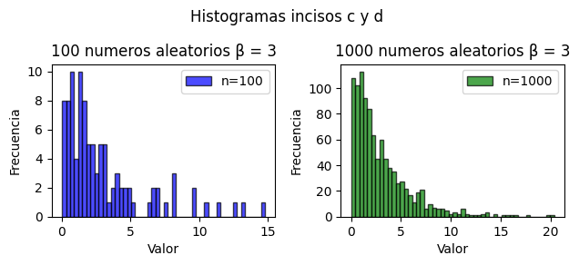

```python
plt.subplot(2,2,1)
plt.hist(exponencial_100_beta3, bins=50, color='blue', edgecolor='black', alpha=0.7, label='n=100')
plt.title('100 numeros aleatorios β = 3')
plt.xlabel('Valor')
plt.ylabel('Frecuencia')
plt.legend()
plt.subplot(2,2,2)
plt.hist(exponencial_1000_beta3, bins=50, color='green', edgecolor='black', alpha=0.7, label='n=1000')
plt.title('1000 numeros aleatorios β = 3')
plt.xlabel('Valor')
plt.ylabel('Frecuencia')
plt.legend()

plt.suptitle("Histogramas incisos c y d")
plt.tight_layout()
plt.show()
```

f. Comparacion de los 3 histogramas

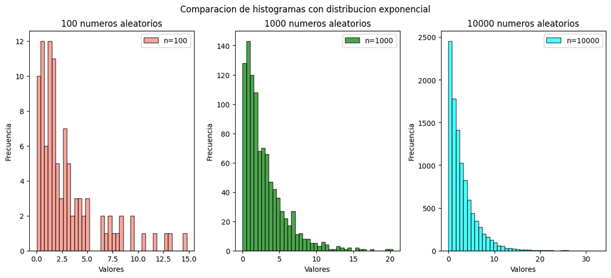

```python
exponencial_10000_beta3 = np.random.exponential(3, 10000)

plt.figure(figsize=(12, 10))

plt.subplot(2,3,1)
plt.hist(exponencial_100_beta3, bins=40, color='salmon', edgecolor='black', alpha=0.7, label='n=100')
plt.title('100 numeros aleatorios')
plt.xlabel('Valores')
plt.ylabel('Frecuencia')
plt.legend()

plt.subplot(2,3,2)
plt.hist(exponencial_1000_beta3, bins=40, color='green', edgecolor='black', alpha=0.7, label='n=1000')
plt.title('1000 numeros aleatorios')
plt.xlabel('Valores')
plt.ylabel('Frecuencia')
plt.legend()

plt.subplot(2,3,3)
plt.hist(exponencial_10000_beta3, bins=40, color='cyan', edgecolor='black', alpha=0.7, label='n=10000')
plt.title('10000 numeros aleatorios')
plt.xlabel('Valores')
plt.ylabel('Frecuencia')
plt.legend()

plt.suptitle("Comparacion de histogramas con distribucion exponencial")
plt.tight_layout()
plt.show()
```

La diferencia visual entre los 3 graficos es que a mayor cantidad de valores tenga la muestra mas semejanza tiene a una funcion exponencial

```python
media_100 = np.mean(exponencial_100_beta3) # Media 100 numeros aleatorios

media_1000 = np.mean(exponencial_1000_beta3) # Media 1000 numeros aleatorios

media_10000 = np.mean(exponencial_10000_beta3) # Media 10000 numeros aleatorios


desvio_100 = np.std(exponencial_100_beta3) # desvio 100 numeros aleatorios

desvio_1000 = np.std(exponencial_1000_beta3) # desvio 1000 numeros aleatorios

desvio_10000 = np.std(exponencial_10000_beta3) # desvio 10000 numeros aleatorios


varianza_100 = np.var(exponencial_100_beta3) # varianza 100 numeros aleatorios

varianza_1000 = np.var(exponencial_1000_beta3) # varianza 1000 numeros aleatorios

varianza_10000 = np.var(exponencial_10000_beta3) # varianza 10000 numeros aleatorios

print("La media es:","\n"," Con 100:", media_100,"\n"," Con 1000:", media_1000,"\n"," Con 10000:", media_10000)
print("El desvio estandar es:","\n"," Con 100:", desvio_100,"\n"," Con 1000:", desvio_1000,"\n"," Con 10000:", desvio_10000)
print("La varianza es:","\n"," Con 100:", varianza_100,"\n"," Con 1000:", varianza_1000,"\n"," Con 10000:", varianza_10000)
```

```
La media es:
  Con 100: 3.040667788069746
  Con 1000: 2.9522802486928397
  Con 10000: 2.981813242626467
El desvio estandar es:
  Con 100: 3.132467392853359
  Con 1000: 2.8666897672810325
  Con 10000: 3.0319265526619463
La varianza es:
  Con 100: 9.81235196728952
  Con 1000: 8.21791022183378
  Con 10000: 9.192578620736555
```

```python
n_de_100 = len(exponencial_100_beta3)
n_de_1000 = len(exponencial_1000_beta3)
n_de_10000 = len(exponencial_10000_beta3)
# Nota: XD?

z = 2.58 # Valor obtenido de la tabla Z para un nivel de confianza del 99%
mult_desvio = 2
def calcular_intervalo_confianza(media_muestral, mult_desvio, desvio_estandar, z, n):
    error_estandar = z * ( (mult_desvio * desvio_estandar) / np.sqrt(n))
    extremo_inferior = media_muestral - error_estandar
    extremo_superior = media_muestral + error_estandar

    return extremo_inferior, extremo_superior

intervalo_100 = calcular_intervalo_confianza(media_100, mult_desvio, desvio_100, z, 100)
intervalo_1000 = calcular_intervalo_confianza(media_1000, mult_desvio, desvio_1000, z, 1000)
intervalo_10000 = calcular_intervalo_confianza(media_10000, mult_desvio, desvio_10000, z, 10000)

print("Intervalo de confianza estimado para :", intervalo_100)
print("Intervalo de confianza estimado para :", intervalo_1000)
print("Intervalo de confianza estimado para :", intervalo_10000)
```

```
Intervalo de confianza estimado para : (1.4243146133574127, 4.657020962782079)
Intervalo de confianza estimado para : (2.484512367792005, 3.4200481295936744)
Intervalo de confianza estimado para : (2.8253658325091107, 3.1382606527438237)
```